# Comparative Antihypertensive Efficacy of Ramipril, Lisinopril, and Moexipril

Rongrong Qian

2025-09-10

# 1 Introduction

Systolic Blood Pressure (SBP) is a critical clinical metric, representing the arterial pressure during a heartbeat. Elevated SBP, or hypertension, is a primary risk factor for major cardiovascular events, including stroke and heart attack. This report aims to conduct an exploration and comparison of the efficacy of three common antihypertensive drugs: Ramipril, Lisinopril, and Moexipril, in reducing SBP through a small scale clinical study.

The primary objective of this report is to perform a comprehensive and in depth statistical analysis to:

- **Assess Drug Efficacy**: Determine if there are statistically significant differences among the three drugs in reducing mean SBP.
- **Identify the Optimal Medication**: If significant differences exist, identify which drug demonstrates superior performance in reducing blood pressure.
- **Examine Randomization Assumption**: Evaluate the baseline data to check if participants were successfully randomized to the three treatment groups.

This report will employ an Analysis of Covariance (ANCOVA) model, using the baseline SBP as a covariate. This approach allows for a more precise evaluation of the true effects of each drug by controlling for initial differences in blood pressure levels.

# 2 Methods

## 2.1 Data

The data for this study were obtained from a clinical trial designed to compare the efficacy of three blood pressure medications in 12 participants. Participants were randomly assigned to one of three treatment groups (n=4 per group), receiving Ramipril, Lisinopril, or Moexipril.

For each participant, the dataset comprised four variables: a unique subject identifier, the assigned treatment (drug), and systolic blood pressure (SBP) measured at baseline (before) and post-treatment (after). SBP values were recorded in millimeters of mercury (mmHg).

It should be noted that no other information regarding subject demographics (e.g., age, sex), clinical history, lifestyle factors, or other potential confounders was available.

## 2.2 Statistical Analysis

### 2.2.1 Efficacy Metrics

#### 2.2.1.1 Absolute reduction

To quantify the effectiveness of each medication, a primary outcome variable was defined as the Absolute SBP Change:

$$\Delta = SBP_{Before} - SBP_{After} \quad (mmHg) \tag{1}$$

A larger positive value for this ∆ variable indicates a greater reduction in SBP and, consequently, higher drug efficacy.

#### 2.2.1.2 Percent reduction

$$r = 100 \times \frac{\Delta}{SBP_{Before}} \quad (\%) \tag{2}$$

This controls for the fact that people with higher baseline pressure have more room to decrease.

### 2.2.2 Randomization

To verify that the randomization was successful, the treatment groups at baseline were compared using a permutation test. This statistical method was chosen because it is highly reliable for small sample sizes. As a non-parametric test, it does not require assumptions about the underlying distribution of the data.

The analysis involved the following steps. First, all participants’ pre-test scores were converted into ranks (from lowest to highest). Based on these ranks, an F-statistic was calculated. This statistic provides a single value that summarizes the size of the difference between the groups based on their average ranks.

The core of the test was to challenge the null hypothesis: the assumption that any observed difference between the groups was simply due to random chance. To do this, the simulation process involved repeatedly shuffling the group assignments and recalculating the F-statistic for each new arrangement.

By repeating this process 10,000 times, an empirical null distribution was generated , which shows the full range of F-statistics that could be expected to occur by chance alone. The p-value was calculated by finding the proportion of these simulated F-statistics that were as extreme or more extreme than the one actually observed in this study.

### 2.2.3 Model

To evaluate the efficacy of the three medications, the primary statistical analysis employed an Analysis of Covariance (ANCOVA) model. This approach was used to compare post treatment Systolic Blood Pressure (SBP) among the three drug groups while adjusting for baseline SBP values. The model operated under the assumption of equal slopes across the treatment groups, and Lisinopril served as the reference group for all comparisons. The formal specification of the model is:

$$SBP_{After_{ij}} = \beta_0 + \beta_1 \cdot SBP_{Before} + \beta_2 \cdot
I_{Moexipril} + \beta_3 \cdot I_{Ramipril} + \epsilon_{ij} \tag{3}$$

Where:

- $I_{Moexipril}$ = 1 if Moexipril is administered, 0 if not (indicator variable)
- $I_{Ramipril}$ = 1 if Ramipril is administered, 0 if not (indicator variable)
- Lisinopril is the baseline group (both indicators = 0)
- $\beta_0$ is the estimated mean post-study BP for Lisinopril when pre-study BP = 0 (non-interp)
- $\beta_1$ is the fixed effect of pre-study BP on post-study BP, regardless of drug
- $\beta_2$ is the (adjusted) estimated change in mean post-study BP for Moexipril as compared to Lisinopril (baseline group)
- $\beta_3$ is the (adjusted) estimated change in mean post-study BP for Ramipril as compared to Lisinopril (baseline group)
- $\epsilon_{ij}$ is the random error associated with the $j^{th}$ subject in the $i^{th}$ drug group

## 2.3 Software

All statistical analyses and visualizations were performed using `R (version 4.4.2)` and `RStudio (version 2025.05.0)`. Key packages utilized include `dplyr` for data manipulation, `ggplot2` for visualization, `kableExtra` for creating formatted tables, and the `car` for ANCOVA and assumption testing, while `emmeans` facilitated post-hoc comparisons.

# 3 Results

## 3.1 Exploratory Data Analysis Results

### 3.1.1 Visual Comparison of SBP Reduction

#### 3.1.1.1 Descriptive summaries

To begin the efficacy comparison, the descriptive statistics for each treatment group were first examined. Table 1 presents a summary of the SBP values before and after treatment, along with the calculated SBP reduction and mean percent reduction.

Table 1: Descriptive Summary of SBP (mmHg) by Medication

| Medication | N | Baseline Mean | Baseline SD | Post-treatment Mean | Post-treatment SD | Mean Reduction | Reduction SD | Mean % Reduction |
| --- | --- | --- | --- | --- | --- | --- | --- | --- |
| Lisinopril | 4 | 170.2 | 12.4 | 131.5 | 9.7 | 38.8 | 15.0 | 22.5 |
| Moexipril | 4 | 172.8 | 13.4 | 128.2 | 4.9 | 44.5 | 8.8 | 25.6 |
| Ramipril | 4 | 179.8 | 13.3 | 147.8 | 9.3 | 32.0 | 6.4 | 17.7 |

#### 3.1.1.2 Paired line plot of individual SBP changes

Given the small sample size of this study, presenting aggregated statistics alone can be misleading. To provide a more transparent and detailed view of the treatment effects, Figure 1 visualizes the SBP trend for every individual subject before and after treatment.

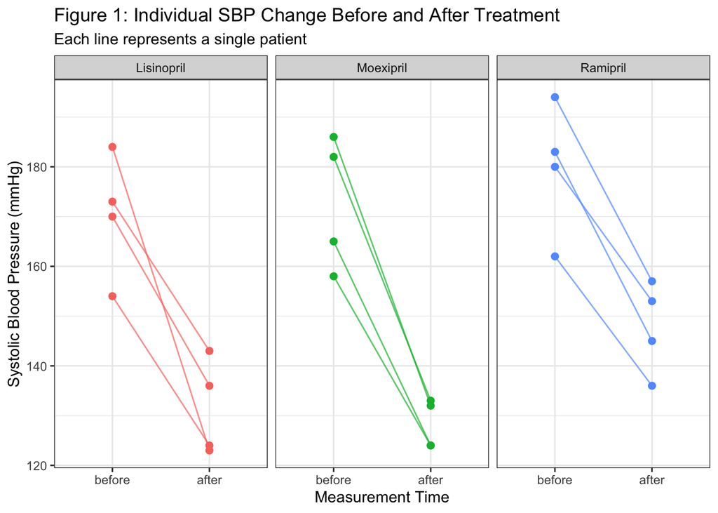

As shown in Figure 1, the plot visually confirms that SBP decreased for all subjects across all treatments. It also highlights key differences among the groups: the Lisinopril trajectories (red) show effective but highly variable responses, the Moexipril trajectories (green) show strong and consistent reductions, and the Ramipril trajectories (blue) show reductions from a visibly higher baseline SBP.

There is one participant in the Lisinopril group shows a substantially larger SBP reduction than others in the group, marking it as a potential outlier. Given the small sample size, this single data point could disproportionately affect the group’s overall results. The reason for this is unclear and could range from situational factors, like an artificially high baseline reading due to stress (a “white coat” effect), to a data entry error. To address this uncertainty, if circumstances permitted, it would be ideal to remeasure this participant’s blood pressure to confirm the validity of this observation.

#### 3.1.1.3 Visualizing Drug Efficacy

To further illustrate the differences in treatment efficacy, a Jitter plot of the absolute SBP change (∆) and percent SBP reduction (r) for each medication group is presented below.

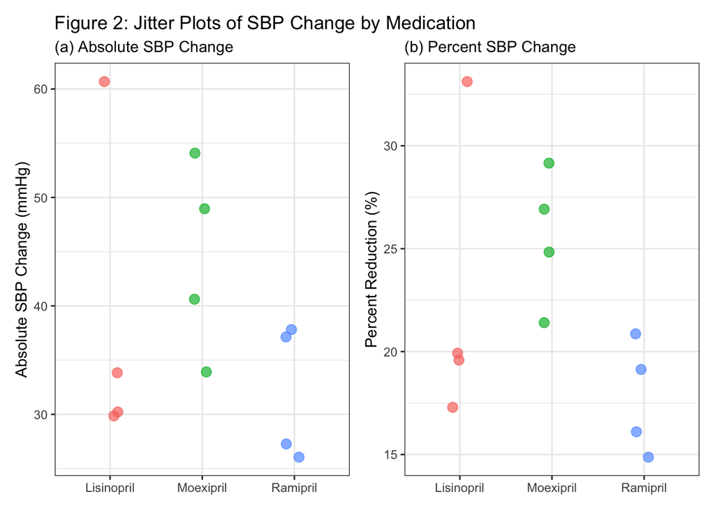

In Figure 2, both jitter plots provide a clear visual representation of the distribution of SBP changes for each medication. Moexipril consistently shows the highest reductions, while Ramipril shows the lowest. Lisinopril’s results are more variable, with one outlier significantly affecting the mean.

Since the absolute change (∆) and percent change (r) plots convey similar information, so either metric could be used for the efficacy comparison.

#### 3.1.1.4 Relationship Between Baseline SBP and SBP Reduction

To explore whether baseline SBP influenced the magnitude of SBP reduction, a scatter plot with a regression line was created. This visualization helps to assess if patients with higher initial SBP experienced greater reductions, which could confound the interpretation of drug efficacy.

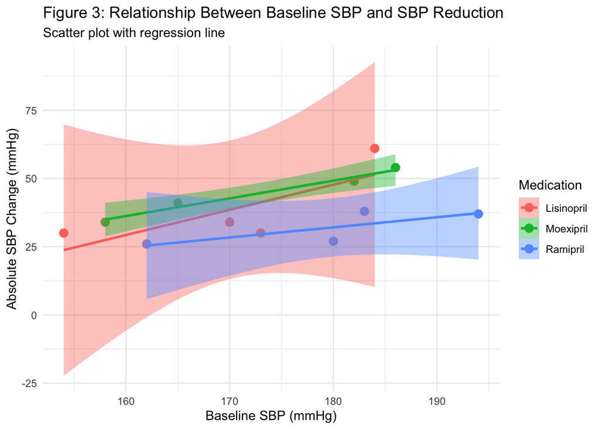

The scatter plot indicates a positive correlation between baseline SBP and the magnitude of SBP reduction. This suggests that observations with higher initial SBP tend to experience larger reductions, which could bias the efficacy comparison among drugs.

### 3.1.2 Relationship Between Baseline SBP and Post-treatment SBP

To further investigate the relationship between baseline SBP and post-treatment SBP, another scatter plot with a regression line Figure 4 was created. This visualization helps to assess how baseline SBP influences the final SBP after treatment.

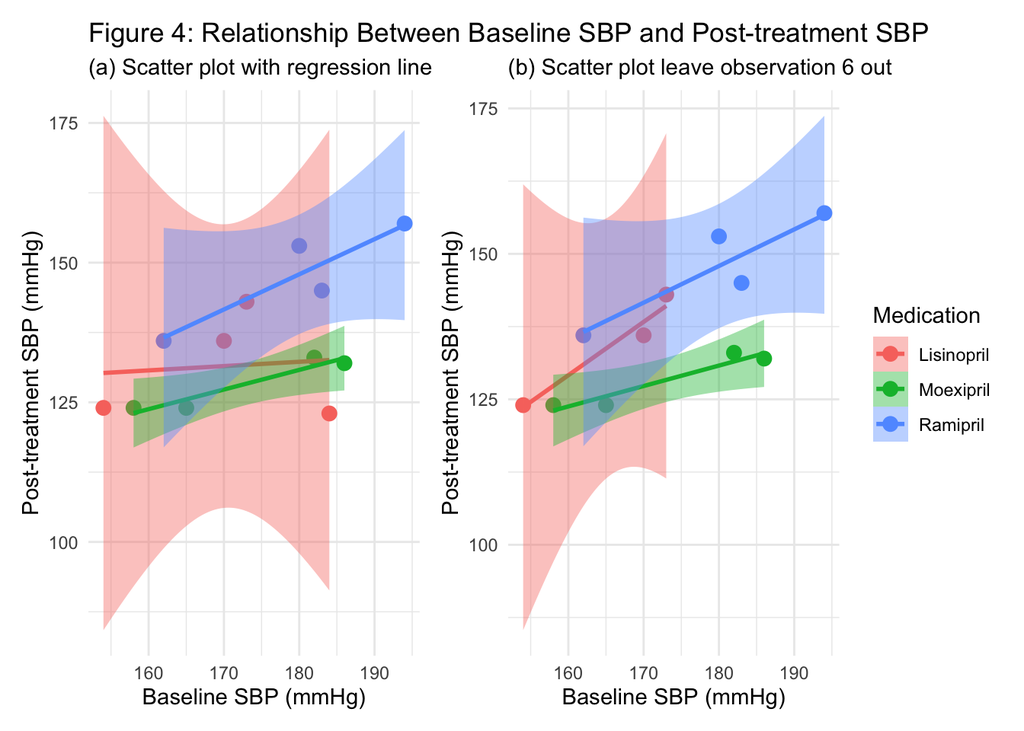

Figure 4 indicates a strong positive correlation between baseline SBP and post-treatment SBP. The post-treatment SBP was chosen as the response variable for the final model since it is more clinically relevant and more interpretable than SBP change.

As depicted Figure 4 (a), Moexipril and Ramipril display largely parallel slopes, while Lisinopril appears nearly flat, driven by one single observation (subject 6) with a very high baseline SBP (>180 mmHg) and a large reduction. With only four data points, this observation has significant leverage, pulling the regression line down and strongly influencing its direction. When this point is excluded (Figure 4 (b)), the Lisinopril slope becomes steeper and roughly parallel to the others.

Although influential, subject 6 should not be removed given the small sample size and the possibility that this reflects a genuine biological response. Excluding it could mask a real interaction effect. Therefore, all observations were retained, and the potential interaction was formally tested in subsequent analyses.

## 3.2 Model Selection

### 3.2.2 Interaction Check

It was hypothesized that the effect of drugs could be dependent on patients’ initial SBP levels, as different treatments might exhibit varied efficacy across the range of baseline pressures. This potential dependency is modeled as an interaction effect. Therefore, the interaction between baseline SBP and drug type was formally tested.

A linear model was fitted that included the main effects for baseline SBP (before) and drug group (drug), as well as their interaction term (before * drug). The significance of this interaction was evaluated using a Type II Analysis of Variance.

Table 2: ANOVA Table for the Interaction Model

|  | Sum Sq | Df | F value | Pr(>F) |
| --- | --- | --- | --- | --- |
| before | 203.37396 | 1 | 3.6547220 | 0.1044567 |
| drug | 569.47704 | 2 | 5.1168801 | 0.0504890 |
| before:drug | 75.24463 | 2 | 0.6760901 | 0.5435072 |
| Residuals | 333.88141 | 6 | NA | NA |

The analysis showed in table 2 is that the interaction term between baseline SBP and drug group was not statistically significant (F(2, 6) = 0.68, p = 0.54). This result supports the assumption of parallel slopes across the treatment groups. Therefore, the analysis was conducted using a main effect ANCOVA model without interaction terms.

## 3.3 Model Diagnostics

To validate the assumptions of the ANCOVA model, a series of diagnostic tests were performed on the final ANCOVA model to ensure that the assumptions of the linear model were met. These checks included tests for the homoscedasticity (constant variances), normality of residuals, and the presence of influential outliers.

### 3.3.1 Independence

This assumption is primarily met by the study design rather than a statistical test. In this study, the 12 participants were distinct individuals who were measured independently. Therefore, there is no reason to believe that the observations are correlated, and the independence assumption is considered to be satisfied.

### 3.3.2 Homoscedasticity (Constant Variance)

The assumption of constant variance of residuals across all levels of the independent variables, was evaluated using Levene’s test. A non-significant p-value (> 0.05) suggests that the variances are equal across groups.

Table 3: Levene’s Test for Constant Variance

|  | Df | F value | Pr(>F) |
| --- | --- | --- | --- |
| group | 2 | 3.585 | 0.072 |
|  | 9 | NA | NA |

The Levene’s test produced an F statistic of 3.585 with a p-value of 0.072, indicating that the variances of residuals are roughly equal across the drug groups. This supports the assumption of constant variance.

### 3.3.3 Normality of Residuals

The normality assumption was assessed using the Shapiro-Wilk test. A non-significant p-value (> 0.05) indicates that the residuals do not significantly deviate from normality.

Table 4: Shapiro-Wilk Normality Test

| Statistic | Value |
| --- | --- |
| W | 0.962 |
| p-value | 0.806 |

The Shapiro-Wilk test yielded a W statistic of 0.962 and a p-value of 0.806, indicating that the residuals do not significantly deviate from normality. This supports the assumption of normality.

### 3.3.4 Outliers

To identify any influential outliers that could disproportionately affect the model estimates, Cook’s distance was calculated for each observation. A common threshold for concern is a Cook’s distance greater than 4/n, where n is the sample size.

Table 5: Cook’s Distance for Influential Outliers

| Subject | Cook_s_Distance | Influential |
| --- | --- | --- |
| 1 | 0.081 | No |
| 2 | 0.210 | No |
| 3 | 0.035 | No |
| 4 | 0.058 | No |
| 5 | 0.015 | No |
| 6 | 0.851 | Yes |
| 7 | 0.247 | No |
| 8 | 0.046 | No |
| 9 | 0.007 | No |
| 10 | 0.006 | No |
| 11 | 0.005 | No |
| 12 | 0.006 | No |

The Cook’s distance analysis identified one potentially influential observation (Subject 6) with a Cook’s distance of 0.851, exceeding the threshold of 0.333 (4/n = 4/12). This suggests that this observation may have a significant impact on the model estimates.

However, given the small sample size and the lack of evidence that this point is a data error, it was retained in the analysis to preserve the integrity of the dataset.

## 3.4 ANCOVA Model Fit

Based on the analysis above, a one-way ANCOVA model (without interaction) was fitted to assess the differences in post-treatment SBP among the three drug groups, adjusting for baseline SBP. The model summary and overall ANOVA results are presented below.

Table 6: ANCOVA Coefficients with 95% CI

| term | estimate | std.error | statistic | p.value | CI_Lower | CI_Upper |
| --- | --- | --- | --- | --- | --- | --- |
| (Intercept) | 69.393 | 31.349 | 2.214 | 0.058 | -2.896 | 141.683 |
| before | 0.365 | 0.183 | 1.994 | 0.081 | -0.057 | 0.787 |
| drugMoexipril | -4.162 | 5.077 | -0.820 | 0.436 | -15.870 | 7.546 |
| drugRamipril | 12.784 | 5.347 | 2.391 | 0.044 | 0.454 | 25.115 |

Table 7: ANCOVA Model Summary

| Statistic | Value |
| --- | --- |
| R-squared | 0.725 |
| Adj R-squared | 0.621 |
| F-statistic | 7.020 |
| RMSE | 7.150 |

Table 8: Type-II ANOVA for ANCOVA Model

|  | Sum Sq | Df | F value | Pr(>F) |
| --- | --- | --- | --- | --- |
| before | 203.374 | 1 | 3.977 | 0.081 |
| drug | 569.477 | 2 | 5.568 | 0.031 |
| Residuals | 409.126 | 8 | NA | NA |

The ANCOVA model explained a substantial portion of the variance in post-treatment SBP (R² = 0.725, Adjusted R² = 0.621 were shown in table 7), indicating there are 72.5% variability can be explained by this model. The overall F-test was statistically significant since F(3, 8) = 7.02 > F(0.95, 3,8) = 4.066, suggesting that at least one of the predictors (baseline SBP or drug group) is significantly associated with post-treatment SBP. The root mean square error (RMSE) of 7.15 mmHg indicates the average deviation of observed post-treatment SBP values from those predicted by the model.

Type-II ANOVA further revealed that the treatment group (drug) effect was significant (F(2, 8) = 5.57, p = 0.031), while the baseline SBP covariate approached significance (F(1, 8) = 3.98, p = 0.081).

**These results suggest that post-treatment SBP differs across drug groups, after adjusting for baseline levels.**

## 3.5 Pairwise Comparisons

To determine which specific drug groups differ significantly in their adjusted mean post-treatment SBP, pairwise comparisons were conducted using Tukey’s Honest Significant Difference (HSD) test. This method controls for multiple comparisons and provides adjusted p-values for each pairwise contrast.

Table 9: Adjusted Means of Post-treatment SBP with 95% CI

| drug | emmean | SE | df | lower.CL | upper.CL | t.ratio | p.value |
| --- | --- | --- | --- | --- | --- | --- | --- |
| Lisinopril | 132.96 | 3.65 | 8 | 124.54 | 141.38 | 36.43 | 0 |
| Moexipril | 128.80 | 3.59 | 8 | 120.53 | 137.07 | 35.92 | 0 |
| Ramipril | 145.74 | 3.71 | 8 | 137.18 | 154.31 | 39.24 | 0 |

Table 10: Pairwise Comparisons of Adjusted Means

| term | contrast | null.value | estimate | std.error | df | statistic | adj.p.value |
| --- | --- | --- | --- | --- | --- | --- | --- |
| drug | Lisinopril - Moexipril | 0 | 4.162 | 5.077 | 8 | 0.820 | 0.702 |
| drug | Lisinopril - Ramipril | 0 | -12.784 | 5.347 | 8 | -2.391 | 0.099 |
| drug | Moexipril - Ramipril | 0 | -16.946 | 5.216 | 8 | -3.249 | 0.028 |

Overall, these results suggest that Moexipril is the most effective drug in reducing SBP, significantly outperforming Ramipril, while Lisinopril’s efficacy is intermediate and not significantly different from either of the other two drugs.

## 3.6 Randomization

A permutation test on the ranks of baseline Systolic Blood Pressure (SBP) was conducted to assess the success of randomization.

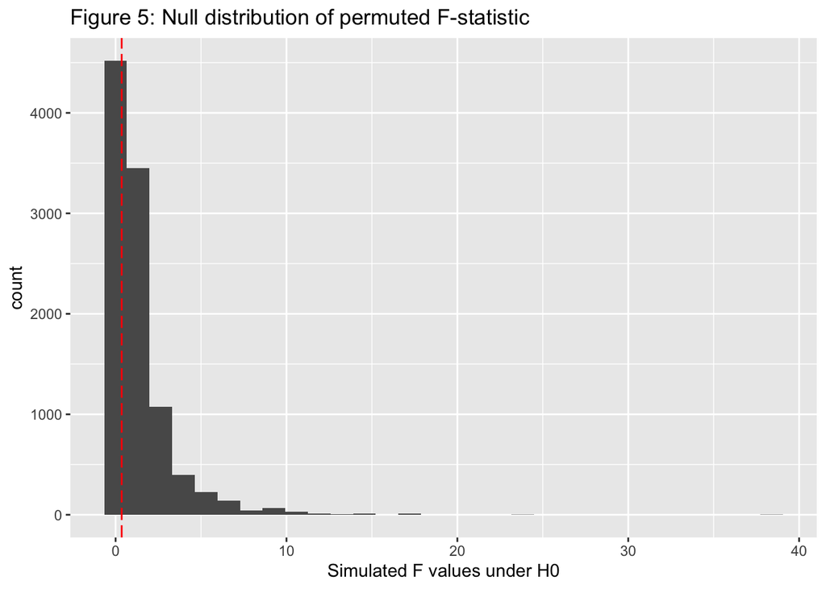

Table 11: Permutation Test for Baseline SBP Differences by Drug Group

| Statistic | Value |
| --- | --- |
| Observed F-statistic | 0.357 |
| Permutation p-value | 0.676 |

The high p-value indicates no evidence of a systematic difference between the treatment groups at baseline, confirming the randomization was successful.

# 4 Discussion

## 4.1 Conclusions

These results carry clear clinical implications. When safety and cost are comparable, Moexipril should be the preferred medication for patients similar to this sample, whereas Ramipril should be avoided. This study also highlighted that the difference between Moexipril and Ramipril was not only statistically significant but also clinically meaningful at approximately 17 mmHg.

## 4.2 Limitations

This study has several limitations. First, the small sample size of 12 participants (n=4 per group) limits the statistical power of our analyses and increases the risk of a Type II error. Consequently, the findings should be interpreted as preliminary. Second, the absence of data on participant demographics (e.g., age, sex), clinical history, or lifestyle factors prevented us from controlling for potential confounding variables, which may influence the observed treatment effects.

Therefore, the clear next step is to conduct a larger, more comprehensive clinical trial to validate these initial findings. Such a study should include a richer set of covariates to allow for a more robust analysis.

# 5 References

1. Hughes, M. (2025, September 10). Practicum in Data Analysis. STA660, Miami University. https://miamioh.instructure.com/courses/237421/pages/project-1-documents?module_item_id=6017368.
2. Cohen, J. (1988). Statistical Power Analysis for the Behavioral Sciences (2nd ed.). Lawrence Erlbaum Associates.
3. Zhang, Z., et al. (2019). Balance diagnostics after propensity score matching. Annals of Translational Medicine, 7(1), 16.
4. John Wiley & Sons. Montgomery, D. C. (2019). Design and analysis of experiments (10th ed.).
5. Vickers, A. J., & Altman, D. G. (2001). The use of percentage change from baseline as an outcome in a controlled trial is statistically inefficient: a simulation study. BMC Medical Research Methodology, 1(1),6.
6. Levene, H. (1960). Robust tests for equality of variances. In I. Olkin, S. G. Ghurye, W. Hoeffding, W. G. Madow, & H. B. Mann (Eds.), Contributions to Probability and Statistics: Essays in Honor of Harold Hotelling (pp. 278-292). Stanford University Press.
7. R Core Team (2024). *R: A Language and Environment for Statistical Computing*. R Foundation for Statistical Computing, Vienna, Austria. https://www.R-project.org/.
8. Wickham H, Hester J, Bryan J (2024). *readr: Read Rectangular Text Data*. R package version 2.1.5, https://CRAN.R-project.org/package=readr.
9. Wickham H, François R, Henry L, Müller K, Vaughan D (2023). *dplyr: A Grammar of Data Manipulation*. R package version 1.1.4, https://CRAN.R-project.org/package=dplyr.
10. Wickham H, Averick M, Bryan J, Chang W, McGowan LD, François R, Grolemund G, Hayes A, Henry L, Hester J, Kuhn M, Pedersen TL, Miller E, Bache SM, Müller K, Ooms J, Robinson D, Seidel DP, Spinu V, Takahashi K, Vaughan D, Wilke C, Woo K, Yutani H (2019). “Welcome to the tidyverse.” *Journal of Open Source Software*, *4*(43), 1686. doi:10.21105/joss.01686 https://doi.org/10.21105/joss.01686.
11. Wickham H, Henry L (2025). *purrr: Functional Programming Tools*. R package version 1.0.4, https://CRAN.R-project.org/package=purrr.
12. Xie Y (2025). *knitr: A General-Purpose Package for Dynamic Report Generation in R*. R package version 1.50, https://yihui.org/knitr/.
13. Zhu H (2024). *kableExtra: Construct Complex Table with ‘kable’ and Pipe Syntax*. R package version 1.4.0, https://CRAN.R-project.org/package=kableExtra.
14. Pedersen T (2024). *patchwork: The Composer of Plots*. R package version 1.3.0, https://CRAN.R-project.org/package=patchwork.